# Storm impact on people health and economy

This report analyse the effects of weather events, as specified by the NOAA, on people health and economic consequences.  
These weather events are listed within the ‘evtypes’ vector.  
Effects on population health have number of fatalities and injuries as a result of that event.  
Economic consequences have include size of property and crop damage because of each event.  
In order to find the most harmful events, the 30 largest of each original ‘EVTYPE’ are found as a total of fatalities and injuries, and each of these events is then assigned to the corresponding NOAA weather event from the ‘evtypes’ vector.  
The data shown at the end may not reflect exact number of fatalities and injuries, however, as only the smaller events have been left out of this calculation, there should not be a noticeable difference from the true data.  
Finally, two plot are shown - each plot demonstrate impact of various event type on health and economy.

## Data Processing

Read the biz2 file. Read vector EVTYPE Make a vector data_hram that consist of injuries, fatalities Make a vector data cost that have Property and Crop Damages

Calculate Fatalities

Calculate injuries

Combine fatalities + injuries

Calcluate property damage

Calculate crop damage

Combine Property and Crop Damages

## Results

### Q. Across the United States, which types of events (as indicated in the EVTYPE variable) are most harmful with respect to population health?

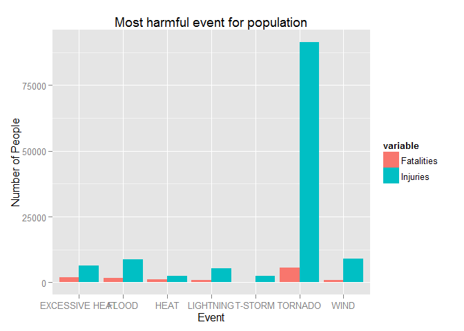

### Q. 2.Across the United States, which types of events have the greatest economic consequences?

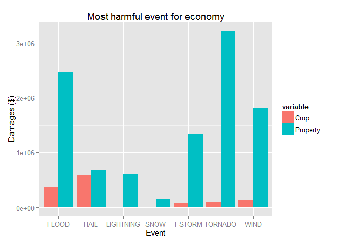